# CSAI3121 - Machine Learning and Intelligent Data Analysis

## Lab 1 - Simple Linear Regression

### Problem 1. Sklearn vs Manual Least-Squares Calculation (Compulsory)

Based on the Advertising dataset, implement a least-square fit for a simple linear regression model using the scikit-learn library. Then manually compute the intercept $\hat b_0$ and slope $\hat b_1$ following the closed-form equations shown on lecture slides 15 and 16. Finally, compare the manually calculated coefficients with the outputs from the sklearn model to verify consistency.

### Implementation Tips:

1. Load the Advertising dataset using Pandas with the first column set as the index:

```
df = pd.read_csv("AdvertisingData.csv", index_col=0)
```

2. Inspect the basic information of the dataset by running `df.info()`. You will observe four feature columns: `TV`, `radio`, `newspaper`, and target column`sales`.
3. Convert the predictor and target variables into valid NumPy array formats for model training:

```
# Reshape predictor X into 2D matrix (required by sklearn)
x = df["TV"].to_numpy().reshape(-1,1)
y = df["sales"].to_numpy()
```

4. Build and train a simple linear regression model on the prepared `x` (TV advertising budget) and `y` (sales) using `sklearn.linear_model.LinearRegression`.
5. Print the estimated intercept `b0` and slope `b1`, formatted to **four decimal places**. The reference output is shown below:

```
Intercept b0 = 7.0326
Slope b1 = 0.0475
Regression line: y_hat = 7.0326 + 0.0475 * TV
```

6. Complete manual least-squares calculation by implementing the closed-form estimation formulas from lecture slides (page 15 and 16):

```
fit_b1 = sum(xi-<x>)(yi-<y>) / sum(xi-<x>)^2
fit_b0 = <y> - fit_b1<x>
```

```
Make sure you have x and y in the same dimension for accurate computations:
```

```
x_1d = x.flatten()
```

7. Compare the manually computed `fit_b1` and `fit_b0` with the coefficients `b0` and `b1` generated by the sklearn model. Check whether the two groups of results are identical, and explain any minor numerical differences if observed.

### Problem 2. Calculate Standard Error, t-statistic and p-value for b1 (Optional)

Assess the linear regression fit by computing the standard error (SE), t-statistic, and p-value for the slope coefficient `b1`. Scikit-learn's `LinearRegression` does not output these inference statistics directly; you will implement them manually. Refer to the formulas on lecture slides:

- Slide 22: Standard error (SE)
- Slide 25: t-statistic and p-value
- Results:

```
SE = 0.0027
t-statistic = 17.6676
p-value = 0.0000
```

### Implementation Tips:

1. Compute the t-statistic value
2. Define the significance level of 0.05 `alpha = 0.05`
3. Compute degrees of freedom `dof = n - 2` Use this when testing a coefficient in a simple linear regression model, where two parameters are estimated: the intercept and slope.
4. Compute the two-tailed p-value `2 * t.cdf(-abs(t_stat), dof)` This selects the lower-tail probability corresponding to the absolute t-statistic and multiplies it by 2 to include the equally extreme tail on the other side of the symmetric t distribution.
5. Compare p-value against the significance level (alpha) to test if there is sufficient evidence to reject H0 at the selected significance level.

# Problem 1.

```python
import pandas as pd
import numpy as np
from sklearn.linear_model import LinearRegression
```

```python
df = pd.read_csv('AdvertisingData.csv', index_col=0)
df.info()
```

```
<class 'pandas.core.frame.DataFrame'>
Index: 200 entries, 1 to 200
Data columns (total 4 columns):
 #   Column     Non-Null Count  Dtype
---  ------     --------------  -----
 0   TV         200 non-null    float64
 1   radio      200 non-null    float64
 2   newspaper  200 non-null    float64
 3   sales      200 non-null    float64
dtypes: float64(4)
memory usage: 7.8 KB
```

```python
x = df["TV"].to_numpy().reshape(-1,1) # reshapes an array into a 2D column vector with 1 column, requires for LinReg
y = df["sales"].to_numpy()
```

```python
model = LinearRegression()
model.fit(x, y)

b0 = model.intercept_.item()  # intercept, use .item to cast the numpy array to scalar
b1 = model.coef_[0].item()   # slope

print(f"Intercept b0 = {b0:.4f}")
print(f"Slope b1 = {b1:.4f}")
print(f"Regression line: y_hat = {b0:.4f} + {b1:.4f} * TV")
```

```
Intercept b0 = 7.0326
Slope b1 = 0.0475
Regression line: y_hat = 7.0326 + 0.0475 * TV
```

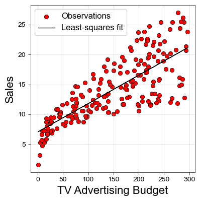

```python
import matplotlib.pyplot as plt

plt.rcParams.update({
    "font.family": "sans-serif",
    "font.sans-serif": ["Helvetica", "Arial", "DejaVu Sans"],
    "font.size": 7,                  # Nature's default size for body text in figures
    "axes.labelsize": 7,             # Size for X and Y axis labels
    "axes.titlesize": 7,             # Size for subfigure titles
    "xtick.labelsize": 10,
    # Slightly smaller font for tick numbers
    "ytick.labelsize": 10,
    "legend.fontsize": 12,
   # Mathematical Text Configuration
    "mathtext.fontset": "custom",    # Forces math formulas to use the main font
    "mathtext.rm": "Helvetica",
    "mathtext.it": "Helvetica:italic",
    "mathtext.bf": "Helvetica:bold",

    # Layout Aesthetics (Clean, Thin lines)
    "axes.linewidth": 0.5,           # Nature prefers thin lines over heavy borders
    "xtick.major.width": 0.5,
    "ytick.major.width": 0.5,
    "xtick.direction": "out",        # Ticks point outward
    "ytick.direction": "out",
    "lines.linewidth": 1.0,          # Standard weight for plot lines
})

y_pred = model.predict(x)

plt.figure(figsize=(4,4))
plt.scatter(df["TV"], df["sales"], c="red", ec="black", lw=0.5, label="Observations")
plt.plot(df["TV"], y_pred, c="black", lw=1, label="Least-squares fit")

plt.xlabel("TV Advertising Budget", fontsize=16)
plt.ylabel("Sales", fontsize=16)

plt.legend(fontsize=12)
plt.grid(alpha=0.3)

plt.tight_layout()
plt.savefig("lab_tv_sales.png", dpi=150, bbox_inches="tight")
plt.show()
```

## Compute fit_b0 and fit_b1 by myself

```
fit_b1 = sum(xi-<x>)(yi-<y>) / sum(xi-<x>)^2
fit_b0 = <y> - fit_b1<x>
```

[output not shown]

```python
# flatten x into 1-D so it has the same dim as y for correct computations
x_1d = x.flatten()

# Compute the means of x and y
x_mean = x_1d.mean()
y_mean = y.mean()

# Compute the numerator and denominator using vectorized operations
numerator = ((x_1d - x_mean) * (y - y_mean)).sum()
denominator = ((x_1d - x_mean) ** 2).sum()

# Calculate fit_b1
fit_b1 = numerator / denominator

# Calculate fit_b0
fit_b0 = y_mean - fit_b1 * x_mean

print(f"Intercept b0 = {fit_b0:.4f}")
print(f"Slope b1 = {fit_b1:.4f}")

print(f"Regression line: y_hat = {fit_b0:.4f} + {fit_b1:.4f} * TV")
```

```
Intercept b0 = 7.0326
Slope b1 = 0.0475
Regression line: y_hat = 7.0326 + 0.0475 * TV
```

# Problem 2.

```python
from scipy import stats
from scipy.stats import t
```